# Code - Response of early life-stages of forest-forming seaweeds from warm-edge and central populations to marine heatwaves

#### 2. Statistical analyses

1. Run LMM for fucoxanthins

```r
my_lmer <- lmer(sqrt(Fucoxanthin) ~ Site_Code.x*Treatment.y + (1|Location), data=Pigments7)
```

```
## boundary (singular) fit: see help('isSingular')
```

```r
summary(my_lmer)
```

```
## Linear mixed model fit by REML ['lmerMod']
## Formula: sqrt(Fucoxanthin) ~ Site_Code.x * Treatment.y + (1 | Location)
##    Data: Pigments7
##
## REML criterion at convergence: -229.8
##
## Scaled residuals:
##     Min      1Q  Median      3Q     Max
## -2.0289 -0.6197 -0.1589  0.5990  2.2257
##
## Random effects:
##  Groups   Name        Variance  Std.Dev.
##  Location (Intercept) 0.0000000 0.00000
##  Residual             0.0003184 0.01784
## Number of obs: 55, groups:  Location, 6
##
## Fixed effects:
##                                          Estimate Std. Error t value
## (Intercept)                             5.077e-02  7.284e-03   6.970
## Site_Code.xBonny Hills                 -4.167e-03  9.636e-03  -0.432
## Site_Code.xCronulla                    -7.651e-04  9.927e-03  -0.077
## Site_Code.xPalm Beach                   7.809e-05  9.404e-03   0.008
## Treatment.yMHW1                         1.194e-02  1.030e-02   1.159
## Site_Code.xBonny Hills:Treatment.yMHW1 -7.669e-03  1.448e-02  -0.530
## Site_Code.xCronulla:Treatment.yMHW1    -7.634e-03  1.383e-02  -0.552
## Site_Code.xPalm Beach:Treatment.yMHW1  -1.335e-02  1.395e-02  -0.957
##
## Correlation of Fixed Effects:
##             (Intr) St_C.BH St_C.C St_C.PB T.MHW1 S_C.BH: S_C.C:
## St_Cd.xBnnH -0.756
## St_Cd.xCrnl -0.734  0.555
## St_Cd.xPlmB -0.775  0.586   0.568
## Trtmnt.MHW1 -0.707  0.535   0.519  0.548
## S_C.BH:T.MH  0.503 -0.666  -0.369 -0.390  -0.712
## S_C.C:T.MHW  0.527 -0.398  -0.718 -0.408  -0.745  0.530
## S_C.PB:T.MH  0.522 -0.395  -0.383 -0.674  -0.739  0.526   0.550
## optimizer (nloptwrap) convergence code: 0 (OK)
## boundary (singular) fit: see help('isSingular')
```

```r
my_lmer_anova <- car::Anova(my_lmer)
my_lmer_anova
```

```
## Analysis of Deviance Table (Type II Wald chisquare tests)
##
## Response: sqrt(Fucoxanthin)
##                          Chisq Df Pr(>Chisq)
## Site_Code.x             1.3414  3     0.7193
## Treatment.y             0.8428  1     0.3586
## Site_Code.x:Treatment.y 0.9173  3     0.8212
```

2. Check model assumptions

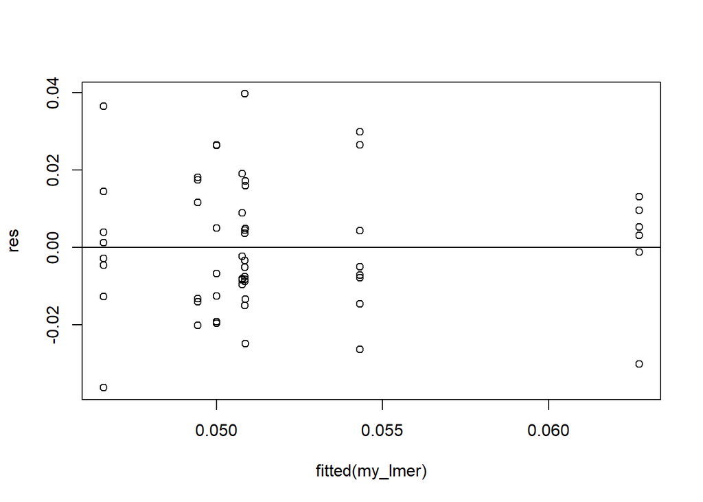

```r
res <- resid(my_lmer)
#produce residual vs. fitted plot
plot(fitted(my_lmer), res)

#add a horizontal line at 0
abline(0,0)
```

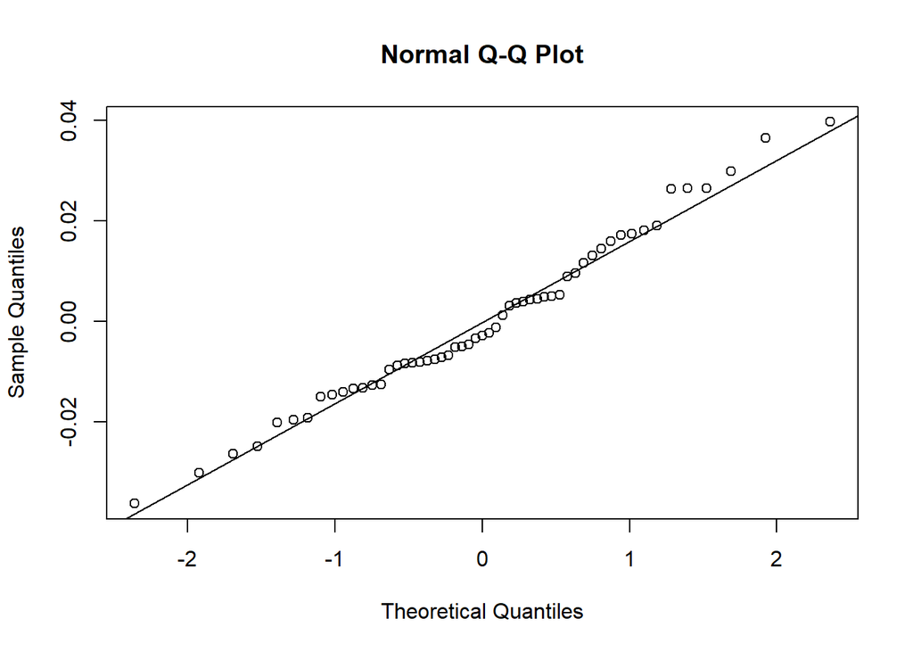

```r
#create Q-Q plot for residuals
qqnorm(res)

#add a straight diagonal line to the plot
qqline(res)
```

## R Session Information

In this part, information about the operating system and R packages attached during the production of this document can be found

```r
sessionInfo() %>% pander
```

**R version 4.4.1 (2024-06-14 ucrt)**

**Platform:** x86_64-w64-mingw32/x64

**locale:** *LC_COLLATE=English_Australia.utf8*, *LC_CTYPE=English_Australia.utf8*, *LC_MONETARY=English_Australia.utf8*, *LC_NUMERIC=C* and *LC_TIME=English_Australia.utf8*

**attached base packages:** *stats*, *graphics*, *grDevices*, *utils*, *datasets*, *methods* and *base*

**other attached packages:** *pander(v.0.6.5)*, *RVAideMemoire(v.0.9-83-7)*, *gt(v.1.0.0)*, *skimr(v.2.1.5)*, *outliers(v.0.15)*, *car(v.3.1-2)*, *carData(v.3.0-5)*, *emmeans(v.1.10.2)*, *lme4(v.1.1-35.4)*, *Matrix(v.1.7-0)*, *ggplot2(v.3.5.1)*, *patchwork(v.1.3.0)*, *dplyr(v.1.1.4)*, *tidyr(v.1.3.1)* and *summarytools(v.1.0.1)*

**loaded via a namespace (and not attached):** *tidyselect(v.1.2.1)*, *farver(v.2.1.2)*, *fastmap(v.1.2.0)*, *TH.data(v.1.1-2)*, *digest(v.0.6.35)*, *estimability(v.1.5.1)*, *timechange(v.0.3.0)*, *lifecycle(v.1.0.4)*, *survival(v.3.6-4)*, *magrittr(v.2.0.3)*, *compiler(v.4.4.1)*, *rlang(v.1.1.4)*, *sass(v.0.4.9)*, *tools(v.4.4.1)*, *yaml(v.2.3.8)*, *knitr(v.1.50)*, *labeling(v.0.4.3)*, *plyr(v.1.8.9)*, *xml2(v.1.3.6)*, *repr(v.1.1.7)*, *multcomp(v.1.4-26)*, *abind(v.1.4-5)*, *withr(v.3.0.2)*, *purrr(v.1.0.2)*, *grid(v.4.4.1)*, *xtable(v.1.8-4)*, *colorspace(v.2.1-0)*, *scales(v.1.3.0)*, *MASS(v.7.3-60.2)*, *cli(v.3.6.2)*, *mvtnorm(v.1.2-5)*, *rmarkdown(v.2.29)*, *ragg(v.1.3.2)*, *generics(v.0.1.3)*, *rstudioapi(v.0.16.0)*, *reshape2(v.1.4.4)*, *minqa(v.1.2.7)*, *cachem(v.1.1.0)*, *stringr(v.1.5.1)*, *splines(v.4.4.1)*, *parallel(v.4.4.1)*, *matrixStats(v.1.5.0)*, *base64enc(v.0.1-3)*, *vctrs(v.0.6.5)*, *boot(v.1.3-30)*, *sandwich(v.3.1-1)*, *jsonlite(v.1.9.1)*, *rapportools(v.1.1)*, *pbkrtest(v.0.5.2)*, *systemfonts(v.1.2.1)*, *magick(v.2.8.3)*, *jquerylib(v.0.1.4)*, *glue(v.1.7.0)*, *nloptr(v.2.1.0)*, *codetools(v.0.2-20)*, *lubridate(v.1.9.3)*, *stringi(v.1.8.4)*, *gtable(v.0.3.6)*, *munsell(v.0.5.1)*, *tibble(v.3.2.1)*, *pillar(v.1.10.1)*, *htmltools(v.0.5.8.1)*, *R6(v.2.6.1)*, *tcltk(v.4.4.1)*, *textshaping(v.0.4.0)*, *evaluate(v.1.0.3)*, *lattice(v.0.22-6)*, *backports(v.1.5.0)*, *broom(v.1.0.6)*, *pryr(v.0.1.6)*, *bslib(v.0.9.0)*, *Rcpp(v.1.0.12)*, *coda(v.0.19-4.1)*, *nlme(v.3.1-167)*, *checkmate(v.2.3.1)*, *xfun(v.0.51)*, *zoo(v.1.8-12)* and *pkgconfig(v.2.0.3)*